# Matplotlib basics

[Matplotlib](http://matplotlib.org/) has become the de facto standard for scientific 2D plotting in Python. It originally attempted to provide a style of interaction similar to Matlab. It allows you to save graphics to different raster and vector image formats, including PDF, JPG, SVG, PNG, BMP and GIF.

Plots and visualizations are one of the most important tasks in data analysis. Having an understanding of the basics of matplotlib is thus an essential aspect of data science in Python.

# En la pagina matplotlib hay una seccion llamada Galery, que ya estan presideñados, y se coge el codigo para personalizarlo.

## Plotting and attributes...

Using matplotlib requires typically importing the `pyplot` object. There is also the option of starting IPython in "pylab" mode, but we will not cover it here. You can plot **in a single cell** by simply using that object. There are different ways of changing the properties of lines...

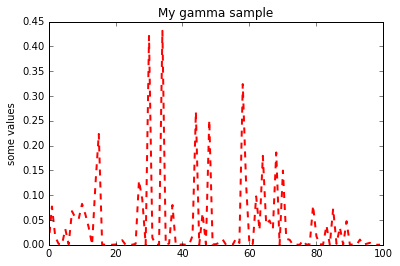

```python
import matplotlib.pyplot as plt
import numpy as np

# Get some random points from a gamma dist.
L = np.random.gamma(0.2, 0.2, 100)

# Tell IPython to use the internal GUI (there are other options, but require correct install of external software)
%matplotlib inline

# Plot and change the line using a format string:
#line, = plt.plot(L, "--")  # Note the comma!

# This is the same as:  line, la coma es para que devuelva la primera linea.
line, = plt.plot(L, linestyle="--")

# Method 2: Use setp and pass the object: step es set property, le añadimos una propiedad sobre la linea anterior.
plt.setp(line, color="r")

# Method 3: Call directly the set_XX on the object:   y la propia linea tiene propiedades.
# es decir, diferentes maneras de hacer lo mismo.
line.set_linewidth(2.0)

# Change figure-related properties:
plt.title("My gamma sample")
plt.ylabel("some values")
```

```
<type 'list'>
```

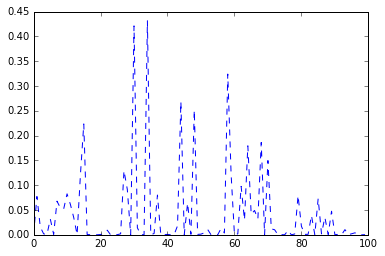

```python
# Note that pyplot returns a list of lines added:
line = plt.plot(L, linestyle="--")
print type(line)
```

The complete documentation of format strings is in the docs of the `pyplot` object: http://matplotlib.org/api/pyplot_api.html#matplotlib.pyplot.plot

You can get the available properties for an object using:

```python
plt.setp(line)
```

```
  agg_filter: unknown
  alpha: float (0.0 transparent through 1.0 opaque)
  animated: [True | False]
  antialiased or aa: [True | False]
  axes: an :class:`~matplotlib.axes.Axes` instance
  clip_box: a :class:`matplotlib.transforms.Bbox` instance
  clip_on: [True | False]
  clip_path: [ (:class:`~matplotlib.path.Path`, :class:`~matplotlib.transforms.Transform`) | :class:`~matplotlib.patches.Patch` | None ]
  color or c: any matplotlib color
  contains: a callable function
  dash_capstyle: ['butt' | 'round' | 'projecting']
  dash_joinstyle: ['miter' | 'round' | 'bevel']
  dashes: sequence of on/off ink in points
  drawstyle: ['default' | 'steps' | 'steps-pre' | 'steps-mid' | 'steps-post']
  figure: a :class:`matplotlib.figure.Figure` instance
  fillstyle: ['full' | 'left' | 'right' | 'bottom' | 'top' | 'none']
  gid: an id string
  label: string or anything printable with '%s' conversion.
  linestyle or ls: ['solid' | 'dashed', 'dashdot', 'dotted' | (offset, on-off-dash-seq) | ``'-'`` | ``'--'`` | ``'-.'`` | ``':'`` | ``'None'`` | ``' '`` | ``''``]
  linewidth or lw: float value in points
  marker: :mod:`A valid marker style <matplotlib.markers>`
  markeredgecolor or mec: any matplotlib color
  markeredgewidth or mew: float value in points
  markerfacecolor or mfc: any matplotlib color
  markerfacecoloralt or mfcalt: any matplotlib color
  markersize or ms: float
  markevery: [None | int | length-2 tuple of int | slice | list/array of int | float | length-2 tuple of float]
  path_effects: unknown
  picker: float distance in points or callable pick function ``fn(artist, event)``
  pickradius: float distance in points
  rasterized: [True | False | None]
  sketch_params: unknown
  snap: unknown
  solid_capstyle: ['butt' | 'round' |  'projecting']
  solid_joinstyle: ['miter' | 'round' | 'bevel']
  transform: a :class:`matplotlib.transforms.Transform` instance
  url: a url string
  visible: [True | False]
  xdata: 1D array
  ydata: 1D array
  zorder: any number
```

## What if you want to do something else with the plot above?

You can change plot properties overall and of the different parts of the plot if you are in the same Notebook cell as many times you want. This means the state of the plot is maintained in the same cell.

But by default, IPython closes the previous plot, so it is no longer accessible, a new one is created. This is to avoid interference between cells.

**la norma : las configuraciones solo afectan a una "celda" del notebook.. una celda genera un grafico, y en otra celda el grafico no existe.

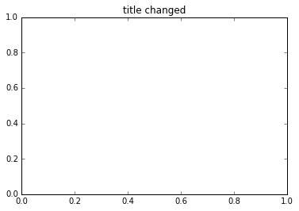

```python
plt.title("title changed")
plt.show()
```

However, you can enable the configuration of IPython so that it does not close previous plots. This can be achieved with a configuration option. **con lo siguiente, se cambia el comportamiento del notebook para que en celdas distintas se pueda toquetear un grafico. No es recomendable!!.

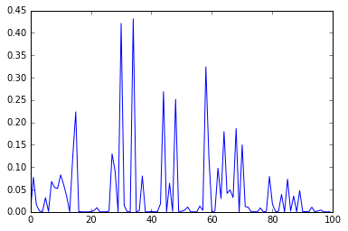

```python
from IPython.core.display import set_matplotlib_close

set_matplotlib_close(False)
# Now we plot again.

# Clear the figures before:
plt.clf()
plt.plot(L)
plt.show()
```

And now we change the plot, and it changes the previous one.

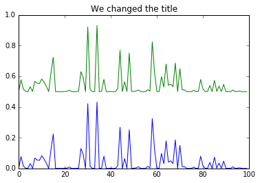

```python
plt.title("We changed the title")
plt.plot([i+0.5 for i in L])
# There can be several lines in the same plot:
plt.show()
```

Now let's revert to the normal behaviour.

```python
set_matplotlib_close(True)
plt.clf()
```

## Several figures, same plot

You can plot several lines with the same plot sentence. **varias figuras mismo grafico.

```
3
```

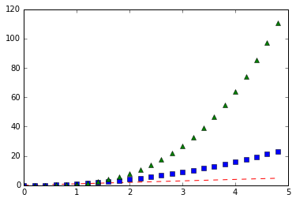

```python
%matplotlib inline
# evenly sampled time at 200ms intervals
t = np.arange(0., 5., 0.2)

# red dashes, blue squares and green triangles, aqui hay 3 serie: t, t en rojo t y t al cuadros en verde, etc..
lines = plt.plot(t, t, 'r--', t, t**2, 'bs', t, t**3, 'g^')

print len(lines)
```

If you use arguments, they apply to all the lines:

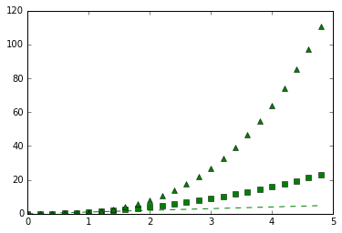

```python
plt.plot(t, t, 'r--', t, t**2, 'bs', t, t**3, 'g^', color="g")
```

## Saving plots

You can easily save a plot. ** para guardar los graficos e incluirlos en un documento.

```
total 9360
drwxr-xr-x  19 msicilia  staff      646 27 may 11:59 ./
drwxr-xr-x  18 msicilia  staff      612 26 may 22:51 ../
-rw-r--r--@  1 msicilia  staff     6148 11 nov  2015 .DS_Store
drwxr-xr-x   9 msicilia  staff      306 12 nov  2015 .ipynb_checkpoints/
-rw-r--r--@  1 msicilia  staff   261776 27 may 11:59 4_1_Matplotlib basics.ipynb
-rw-r--r--@  1 msicilia  staff     7966 24 abr  2015 4_2_Working_with_matplotlib (proposed exercise).ipynb
-rw-r--r--   1 msicilia  staff   138602 18 dic 16:06 4_3_ggplot2.ipynb
-rw-r--r--   1 msicilia  staff   189279 18 dic 16:08 4_4_seaborn_intro.ipynb
-rw-r--r--   1 msicilia  staff  1956438 18 dic 16:12 4_5_Bokeh_Intro.ipynb
-rw-r--r--   1 msicilia  staff      680 12 nov  2015 Untitled.ipynb
-rw-r--r--   1 msicilia  staff  1359962 18 dic 17:04 bloque4.zip
-rw-r--r--@  1 msicilia  staff   258931 11 nov  2015 bloque4_guia.docx
-rw-r--r--@  1 msicilia  staff   220102 11 nov  2015 bloque4_guia.pdf
-rw-r--r--   1 msicilia  staff     6725 11 nov  2015 ejemplo_seaborn.ipynb
-rw-r--r--@  1 msicilia  staff   149035 11 nov  2015 ejercicio1.docx
-rw-r--r--@  1 msicilia  staff    92000 11 nov  2015 ejercicio1.pdf
-rw-r--r--   1 msicilia  staff     7416 27 may 11:59 gamma.pdf
-rw-r--r--   1 msicilia  staff     5914 12 nov  2015 graphics_terminology_seaborn.ipynb
-rwxr-xr-x@  1 msicilia  staff   101776 11 nov  2015 osteoporosis.csv*
```

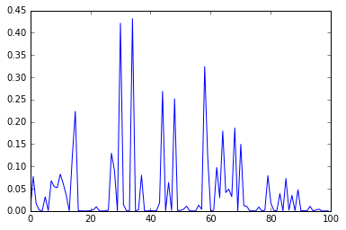

```python
plt.plot(L)
plt.savefig("gamma.pdf", format="pdf")  # Try some arguments as dpi and bbox_inches...
%ls -la
```

## Working with subplots

Using the `subplot` function, you can have several subplots in the same figure. Una sola figura con varios graficos dentro.

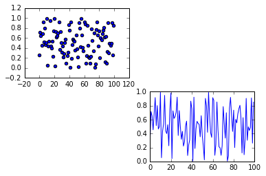

```python
plt.figure(1)  # Creates a figure, this is done by default, you can omit it.
plt.subplot(224) # 2 rows, 2 columns, select the last one. >> 224 : dos filas, dos columnas y posicionate en la 4.

# Create some data and plot it:
data = np.random.random(100)
x = range(len(data))
plt.plot(x, data) # este lo pinta en el cuarto cuadrado.

# Now select other subplot:
plt.subplot(221)
plt.scatter(x, data)  #este plot lo pinta en la 2 filas, dos columnas y lo pinta en el primer cuadrante.
```

## Adding text

You can add text to a plot by using the text function. $\mu $

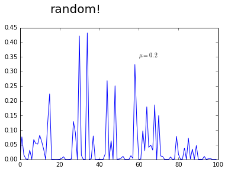

```python
plt.plot(L)
t = plt.text(15, 0.5, "random!") # Note how the coords are provided. añadimos un texto : random. Con 15,05 le indicamos
#las coordenadas dependiendo de los ejes, no son pixels.
t.set_fontsize(20)
t2 = plt.text(60, 0.35, r"$\mu=0.2$") # lenguaje latex (lenguaje matematico para formulas.)
```

**Annotations** are text with some kind of arrow...

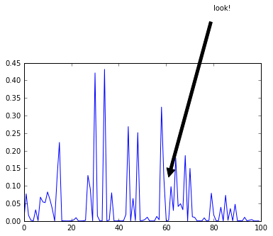

```python
plt.plot(L)
t = plt.annotate('look!', xy=(60, 0.1), xytext=(80, 0.6),
            arrowprops=dict(facecolor='black', shrink=0.05),
            )  # esto es para pintar la flecha.
```

## Plotting multi-dimensional data

If you pass a multidimensional structure, it plots the columns.

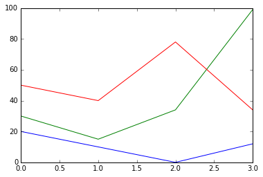

```python
M = [[20, 30, 50],
     [10, 15, 40],
     [ 0, 34, 78],
     [12, 99, 34]]
plt.plot(M)
```

You can plot a single row or column.

```
<Container object of 3 artists>
```

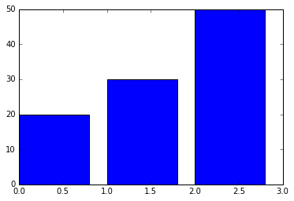

```python
plt.bar(range(len(M[0])), M[0])
```

## Plot goodies, the example of scatter

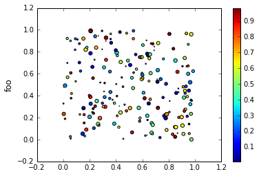

```python
x = np.random.rand(200)
y = np.random.rand(200)
size = np.random.rand(200)*30
color = np.random.rand(200)
plt.scatter(x, y, size, color)
plt.colorbar()
plt.ylabel("foo", fontsize="large")
```

## Plotting with Pandas

You can pass **Series** objects to pyplot, but it is more interesting to use DataFrames.

```python
# Create a time series
import pandas as pd
dates = pd.date_range('20130101',periods=10)
print dates
visits = pd.DataFrame(np.random.randint(20, 300, 20).reshape(10,2),
                      index=dates,
                      columns = ["group A", "group B"])
visits
```

```
DatetimeIndex(['2013-01-01', '2013-01-02', '2013-01-03', '2013-01-04',
               '2013-01-05', '2013-01-06', '2013-01-07', '2013-01-08',
               '2013-01-09', '2013-01-10'],
              dtype='datetime64[ns]', freq='D')
```

|  | group A | group B |
| --- | --- | --- |
| 2013-01-01 | 125 | 123 |
| 2013-01-02 | 292 | 161 |
| 2013-01-03 | 217 | 287 |
| 2013-01-04 | 258 | 214 |
| 2013-01-05 | 127 | 158 |
| 2013-01-06 | 265 | 107 |
| 2013-01-07 | 267 | 119 |
| 2013-01-08 | 175 | 294 |
| 2013-01-09 | 165 | 186 |
| 2013-01-10 | 157 | 37 |

Pandas DataFrame has a `plot` operation that integrates matplotlib with a number of parameters.

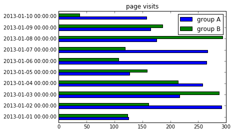

```python
visits.plot(kind="barh", title="page visits")
```

```
array([<matplotlib.axes._subplots.AxesSubplot object at 0x10fc131d0>,
       <matplotlib.axes._subplots.AxesSubplot object at 0x11ac82c50>], dtype=object)
```

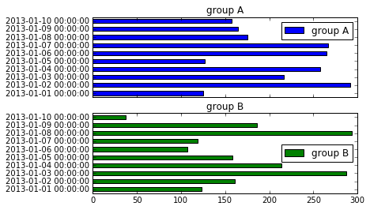

```python
visits.plot(kind="barh", subplots=True)
```

## Looking for more

Just go to the gallery and look at the code of examples: http://matplotlib.org/gallery.html

## Inside Matplotlib objects

Instead of having a single plot, it is often convenient to have several and manipulate them explicitly. You can create several plots using the `figure` function.

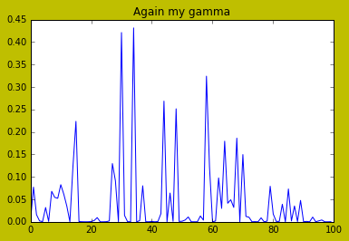

```python
plt.clf()
fig = plt.figure()
ax = fig.add_subplot(1,1,1) # one row, one column, select the first (and unique)
ax.plot(L)
ax.set_title("Again my gamma")

# You can change also Figure properties:
fig.set_facecolor("y")
```

```
<class 'matplotlib.axes._subplots.AxesSubplot'>
```

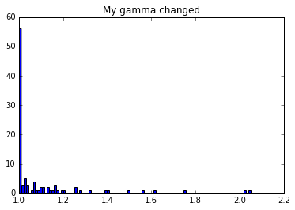

```python
fig2 = plt.figure()
ax2 = fig2.add_subplot(1,1,1) # one row, one column, select the first (and unique)
print type(ax2)
ax2.hist([(i+1)**2 for i in L], bins=100)
ax2.set_title("My gamma changed")
```

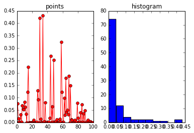

```python
fig3 = plt.figure()

points = fig3.add_subplot(1,2,1) # one row, one column, select the first
points.plot(L)
points.set_title("points")

# Two ways of setting properties:
points.lines[0].set_marker('o')
plt.setp(points.lines[0], color="r")

histogram = fig3.add_subplot(1,2,2) # one row, one column, select the second
histogram.hist(L)
histogram.set_title("histogram")
```

We can change any property for example of a function using setp or set_XX functions, as seen above.